# Duration Calculations

Laura F White

2024-2-7

## Methods

### Estimation of the duration of disease

We leverage countries with two prevalence surveys to determine duration and incidence of TB each year between the two prevalence surveys. To do this, we use data on cures and deaths from TB for each country modeled here. We assume that the ratio of prevalence to incidence is not changing over the studied time period (which implies that disease duration is also not changing). As a first, most simple approach to this problem, we determine what the ratio of prevalence to incidence must be to get us to the value of the second prevalence survey. We calculate prevalence in year $t$, $P_t$ as a function of the prior year’s prevalence, number treated, number who died and the incidence in the prior year, as follows: $P_t=P_{t-1}-C_{t-1}-D_{t-1}+I_{t-1}$, where $C_t$ are the number of treated (or cured) cases of TB in year $t$ and $D_t$ are the number of deaths or self cures from TB in year $t$. We assume that the number who die or self cure have an average duration of 5 years (though we run a sensitivity analysis for this) and estimate the size of this population to be $D_t=(1/\delta_u)*(P_t-C_t)$, where $\delta_u$ is the duration of untreated disease.

We observe prevalence at two time points and have annual treatment and mortality data.

We provide more detail on the estimates of prevalence for each country below. We couple prevalence per 100,000 individuals with the population level estimates when the prevalence surveys were conducted to get the total number of prevalent TB cases, which we use in our calculation.

We loop through a range of duration estimates from 1 to 6 years by 0.01 increments (meaning we consider 501 duration values) and select the durations that are close to the second prevalence survey estimate, assuming that the second prevalence in normally distributed.

To incorporate the uncertainty in the prevalence survey estimates, we use the confidence intervals for each prevalence survey estimate and assume normality to get a standard deviation. We then generate a potential first prevalence survey values from this normal distribution. We estimate annual prevalence until the year of the second prevalence survey using each value in the range of duration estimates, providing 501 vectors of estimated annual prevalence. We use the 501 second prevalence estimates to determine if we will accept or reject the duration value associated with it. To do this, we use the normal distribution to determine if the second prevalence estimate has 0.15 probability of being the same as the observed second prevalence value and accept those that do. This is an Approximate Bayesian approach to estimation and we can change the 0.15 probability, if desired, but more values are rejected. We run the simulation until we accept 1000 duration estimates and we store the simulated first prevalence survey values that were used to get those duration estimates. We then use these 1000 duration values to get the estimated duration and the empirical 95% confidence intervals.

We perform a sensitivity analysis for the assumed duration of untreated duration of TB disease, $\delta_u$. Our primary simulation assumes that this is 5 years. But we also run the simulations for values ranging from 3 to 7 years.

## Results

### Duration estimates

First we provide the duration estimates for each country assuming a five year duration of untreated disease.

| Country | Duration of treated disease | LCL | UCL | Assumed duration of untreated disease |
| --- | --- | --- | --- | --- |
| Cambodia | 3.40478 | 3.02975 | 3.76 | 5 |
| China | 2.44614 | 2.25000 | 2.64 | 5 |
| Indonesia | 2.36869 | 2.09975 | 2.63 | 5 |
| Myanmar | 2.57102 | 2.18000 | 2.93 | 5 |
| Philippines | 3.01748 | 2.79975 | 3.23 | 5 |
| Vietnam | 2.70215 | 2.34000 | 3.06 | 5 |

We also consider all values of untreated disease that range between 3 and 7 years. The following figure shows these results.

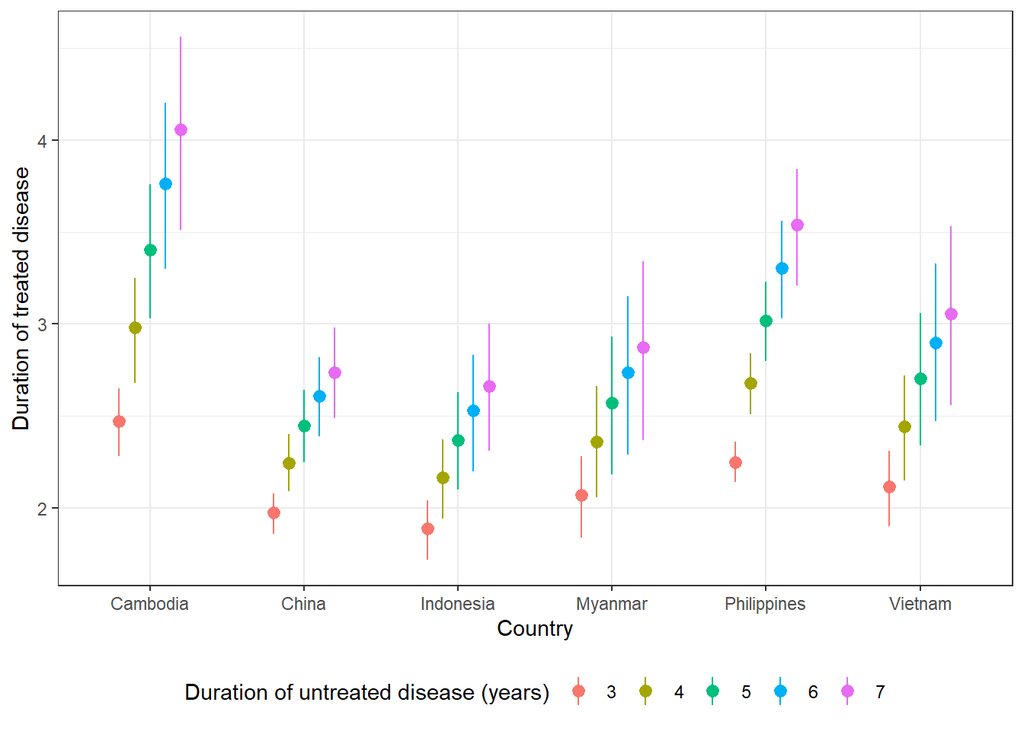

We also show the estimated incidence at the time of the final prevalence survey for each country.

| Country | Incidence per 100k | LCL | UCL | Assumed duration of untreated disease |
| --- | --- | --- | --- | --- |
| Cambodia | 35.08272 | 31.61270 | 39.40568 | 5 |
| China | 591.45803 | 546.80675 | 643.37182 | 5 |
| Indonesia | 716.35126 | 641.97503 | 808.34253 | 5 |
| Myanmar | 85.54987 | 74.46519 | 100.48116 | 5 |
| Philippines | 341.76717 | 318.58140 | 368.75645 | 5 |
| Vietnam | 97.57033 | 85.61409 | 112.95004 | 5 |

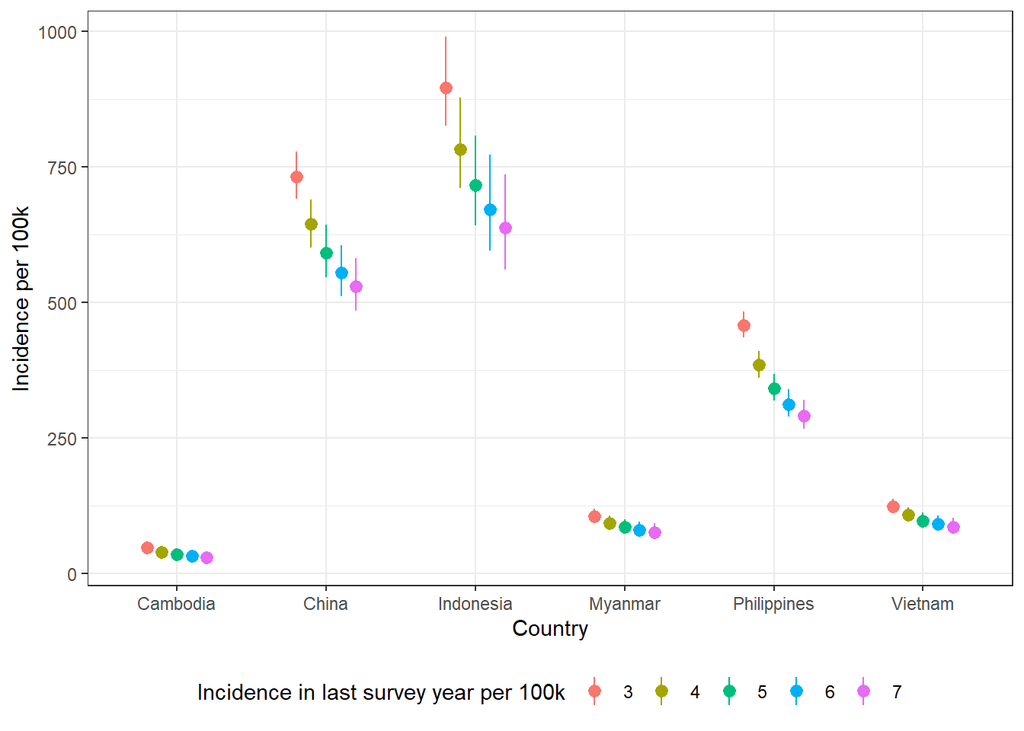

### Estimated annual prevalence

We can also show the annual estimated prevalence for the duration estimate by country.This shows the estimated annual prevalences using the first prevalence survey value for varying values of untreated TB duration.

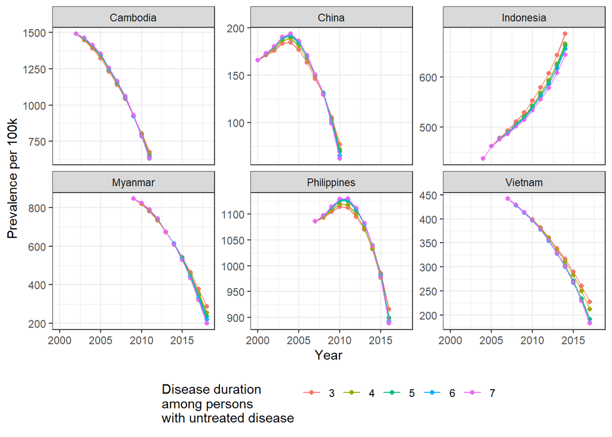

We can also show the uncertainty in prevalence estimates. Following is a plot of the estimated annual prevalence incorporating for uncertainty in the first prevalence value and the uncertainty in the duration estimate.

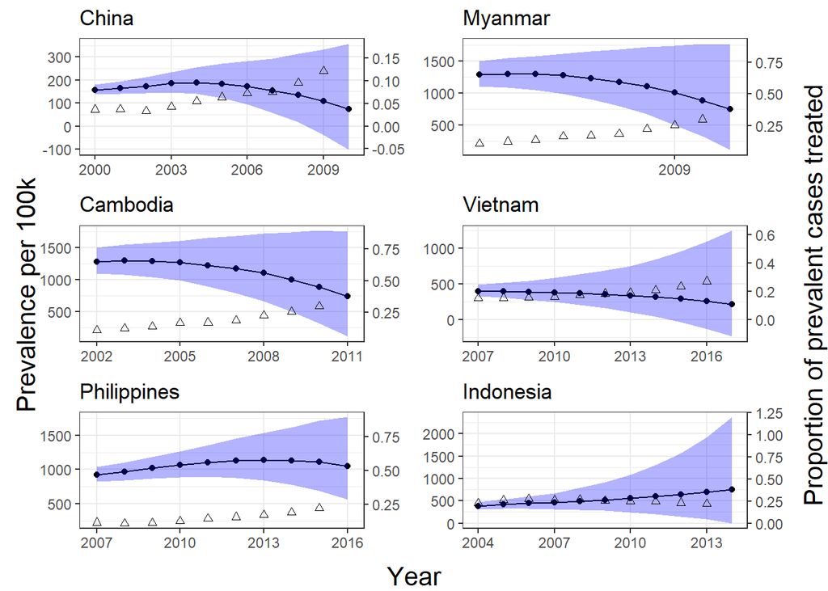

### Cures related to change in prevalence

We first look at the relationship between the proportion of prevalent cases treated and the annual change in prevalence per 100k.

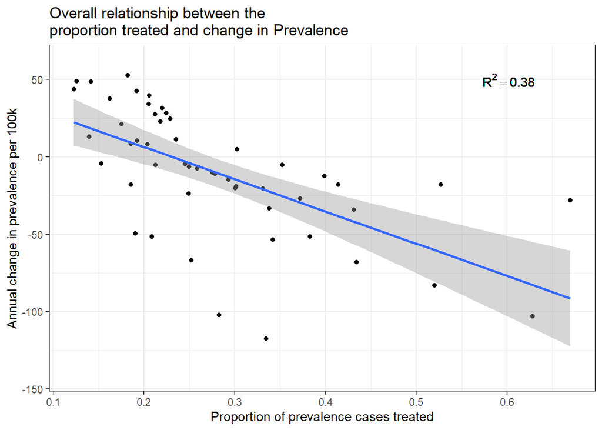

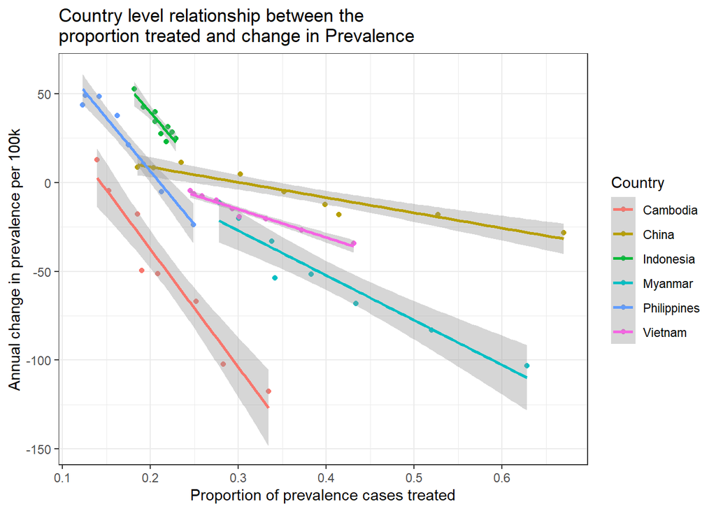

Linear regression fit to relationship between the proportion treated and the annual change in estimated prevalence overall and by country. Estimates shown are per 10% increase in the percent of cases treated.

| Country | Estimate per 0.1 increase | p-value |
| --- | --- | --- |
| Overall | -20.807 | 0e+00 |
| Cambodia | -66.424 | 1e-04 |
| China | -8.593 | 1e-04 |
| Indonesia | -57.636 | 5e-04 |
| Myanmar | -25.205 | 2e-04 |
| Philippines | -59.985 | 0e+00 |
| Vietnam | -15.913 | 0e+00 |

### Cures related to Incidence

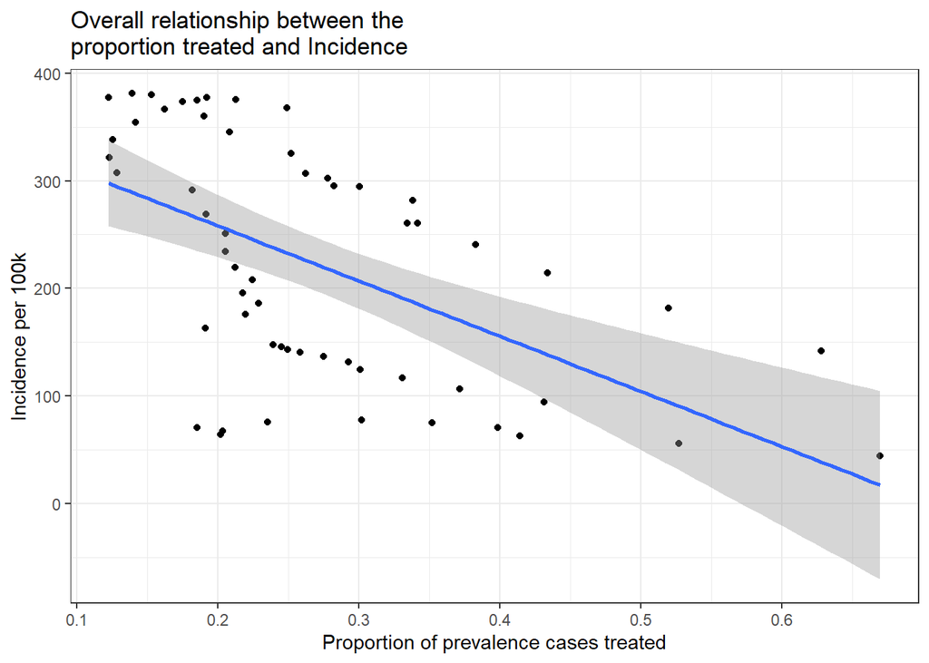

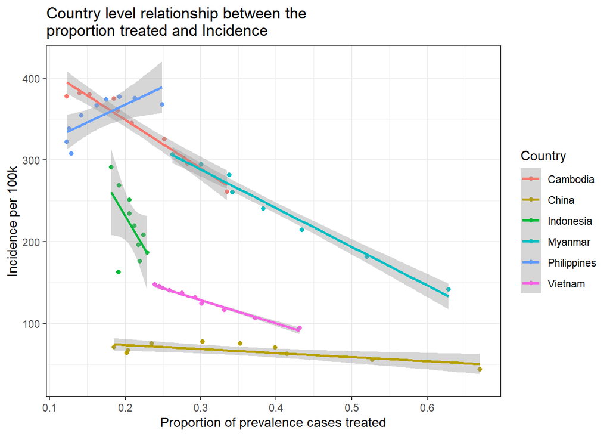

Linear regression fit to relationship between the proportion treated and the annual estimated incidence overall and by country. Estimates shown are per 10% increase in the percent of cases.

| Country | Estimate per 0.1 increase | p-value |
| --- | --- | --- |
| Overall | -51.268 | 0.0000 |
| Cambodia | -59.299 | 0.0000 |
| China | -4.962 | 0.0104 |
| Indonesia | -157.409 | 0.0723 |
| Myanmar | -47.256 | 0.0000 |
| Philippines | 43.418 | 0.0211 |
| Vietnam | -28.620 | 0.0000 |

### Cures per incidence related to Change in prevalance

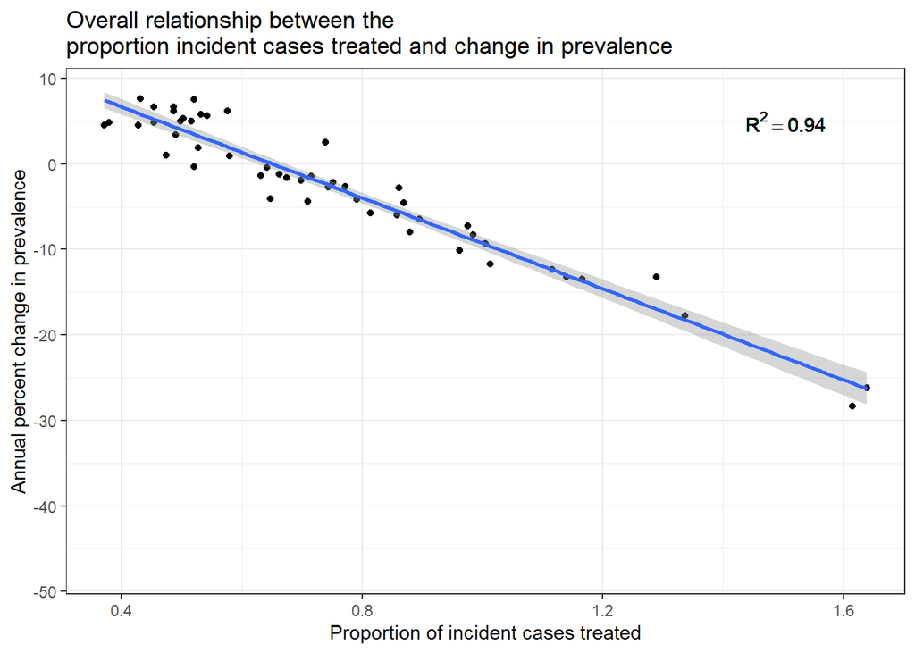

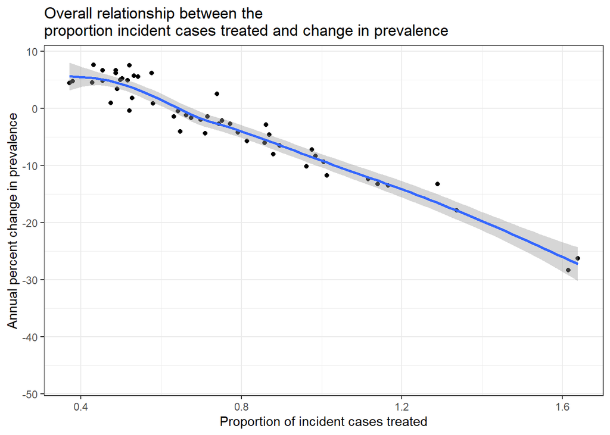

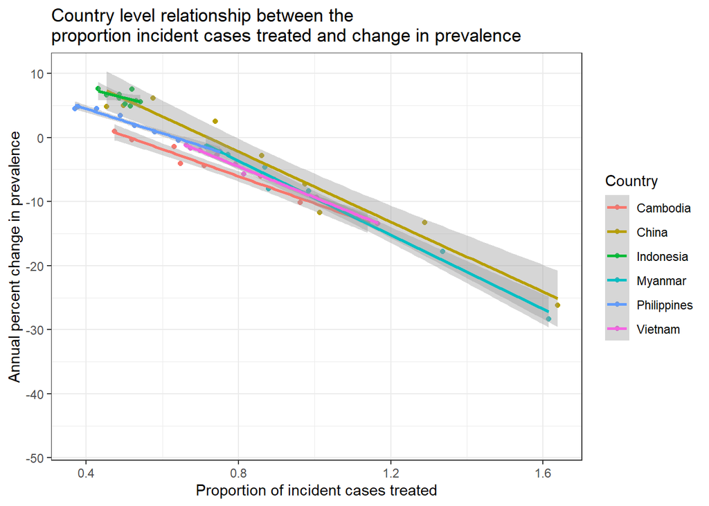

Linear regression fit to relationship between the proportion incident individuals treated and the annual percent change in prevalence overall and by country. Estimates shown are per 10% increase in the proportion of treated cases.

| Country | Estimate per 0.1 increase | p-value |
| --- | --- | --- |
| Overall | -2.660 | 0.0000 |
| Cambodia | -2.115 | 0.0000 |
| China | -2.741 | 0.0000 |
| Indonesia | -1.515 | 0.1032 |
| Myanmar | -2.898 | 0.0000 |
| Philippines | -1.917 | 0.0000 |
| Vietnam | -2.416 | 0.0000 |

### Cures per prevalence related to Change in prevalance

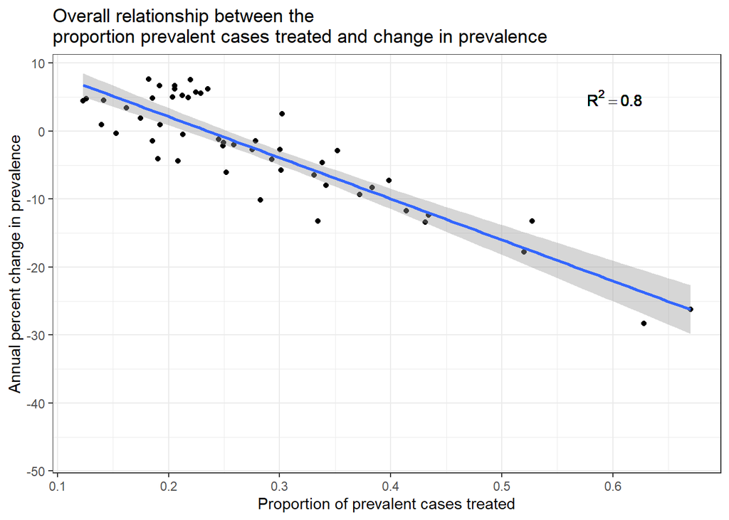

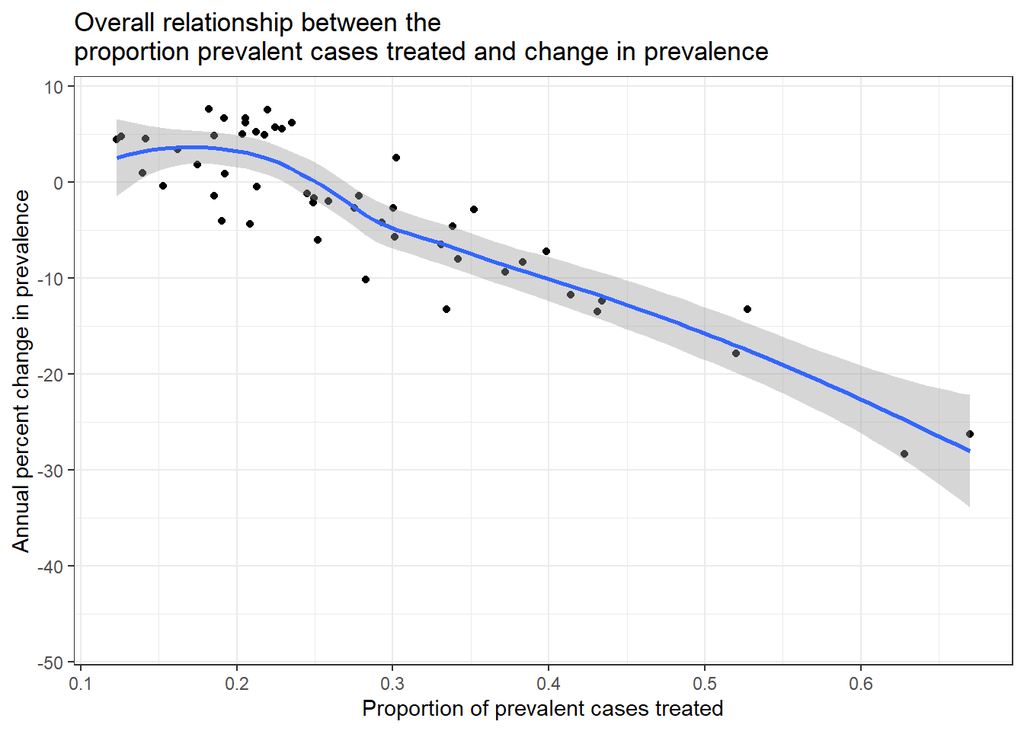

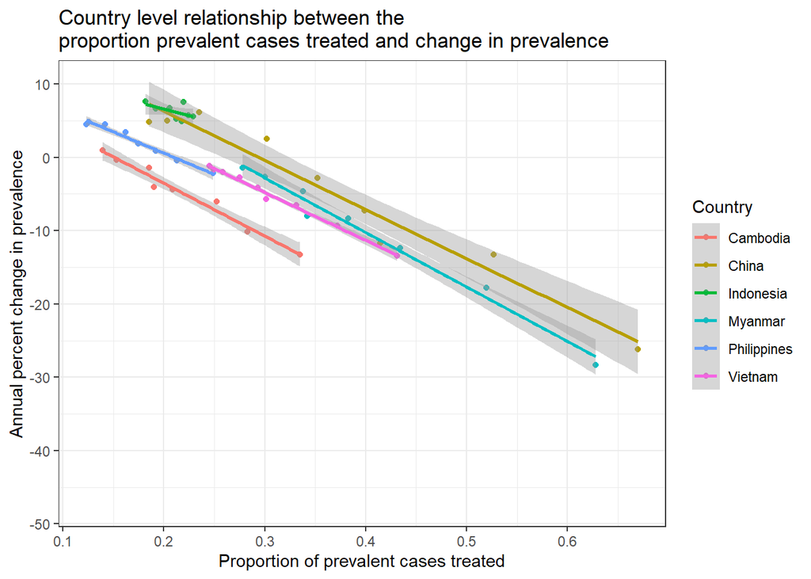

Linear regression fit to relationship between the proportion prevalent individuals treated and the annual percent change in prevalence overall and by country. Estimates shown are per 10% increase in the proportion of treated cases.

| Country | Estimate per 0.1 increase | p-value |
| --- | --- | --- |
| Overall | -6.043 | 0.0000 |
| Cambodia | -7.201 | 0.0000 |
| China | -6.705 | 0.0000 |
| Indonesia | -3.589 | 0.1032 |
| Myanmar | -7.452 | 0.0000 |
| Philippines | -5.786 | 0.0000 |
| Vietnam | -6.528 | 0.0000 |

```
## (Intercept)
##   0.4009081
```

```
## (Intercept)
##   0.5663969
```

## All model results

Finally we show all the model results below.

| Country | Year | Untreated duration | Prevalence | Popn | Prev100k | LCL | UCL | Treated | Proportion treated | UCL.100k | LCL.100k | Incidence100k | PrevDelta | PropIncTreated | trt.rescaled | PrevDeltaPerc |
| --- | --- | --- | --- | --- | --- | --- | --- | --- | --- | --- | --- | --- | --- | --- | --- | --- |
| China | 2000 | 5 | 2095.99070 | 1262645000 | 156.68557 | 1839.890583 | 2404.1874 | 423.0 | 0.2018139 | 179.7248 | 137.540832 | 64.05421 | NA | 0.4936650 | 72.01192 | NA |
| China | 2001 | 5 | 2195.24895 | 1271850000 | 164.90009 | 1884.441761 | 2585.9891 | 447.0 | 0.2036216 | 194.2512 | 141.553247 | 67.41237 | 8.214522 | 0.4980868 | 72.65694 | 4.98 |
| China | 2002 | 5 | 2296.03306 | 1280400000 | 173.33065 | 1897.283007 | 2797.8713 | 426.0 | 0.1855374 | 211.2151 | 143.228464 | 70.85884 | 8.430554 | 0.4538505 | 66.20409 | 4.86 |
| China | 2003 | 5 | 2434.66163 | 1288400000 | 184.74007 | 1920.645988 | 3075.0656 | 573.0 | 0.2353510 | 233.3334 | 145.736994 | 75.52310 | 11.409421 | 0.5757014 | 83.97874 | 6.18 |
| China | 2004 | 5 | 2484.63686 | 1296075000 | 189.51937 | 1834.445082 | 3338.9281 | 751.0 | 0.3022574 | 254.6817 | 139.925027 | 77.47691 | 4.779305 | 0.7393640 | 107.85254 | 2.52 |
| China | 2005 | 5 | 2402.64729 | 1303720000 | 184.29166 | 1584.222889 | 3535.2762 | 846.0 | 0.3521116 | 271.1684 | 121.515578 | 75.33979 | -5.227707 | 0.8613143 | 125.64167 | -2.84 |
| China | 2006 | 5 | 2227.53769 | 1311020000 | 171.86796 | 1217.615187 | 3656.0698 | 888.0 | 0.3986465 | 282.0878 | 93.946352 | 70.26089 | -12.423702 | 0.9751450 | 142.24640 | -7.23 |
| China | 2007 | 5 | 1982.26392 | 1317885000 | 153.85470 | 733.997030 | 3783.4023 | 821.0 | 0.4141729 | 293.6512 | 56.969655 | 62.89693 | -18.013265 | 1.0131249 | 147.78660 | -11.71 |
| China | 2008 | 5 | 1739.37519 | 1324655000 | 135.84623 | 215.744828 | 4021.4772 | 917.0 | 0.5272008 | 314.0798 | 16.849799 | 55.53494 | -18.008463 | 1.2896070 | 188.11760 | -13.26 |
| China | 2009 | 5 | 1368.96951 | 1331260000 | 107.63608 | -476.430703 | 4233.0465 | 917.0 | 0.6698469 | 332.8259 | -37.459661 | 44.00242 | -28.210153 | 1.6385393 | 239.01707 | -26.21 |
| China | 2010 | 5 | 921.22040 | 1337705000 | 72.95957 | -1301.507463 | 4505.4132 | NA | NA | 356.8234 | -103.077861 | 29.82641 | -34.676509 | NA | NA | -47.53 |
| Cambodia | 2002 | 5 | 187.29612 | 12561779 | 1285.14891 | 160.635286 | 218.3050 | 23.0 | 0.1228002 | 1497.9192 | 1102.213210 | 377.45432 | NA | 0.4181076 | 217.06599 | NA |
| Cambodia | 2003 | 5 | 186.44666 | 12787710 | 1298.05579 | 155.386975 | 222.0035 | 26.0 | 0.1394501 | 1545.6052 | 1081.815912 | 381.24513 | 12.906872 | 0.4747968 | 246.49692 | 0.99 |
| Cambodia | 2004 | 5 | 183.11759 | 13016371 | 1293.59251 | 147.916497 | 222.7606 | 28.0 | 0.1529072 | 1573.6413 | 1044.922393 | 379.93424 | -4.463275 | 0.5206154 | 270.28423 | -0.35 |
| Cambodia | 2005 | 5 | 177.87658 | 13246583 | 1275.65983 | 137.805022 | 224.5094 | 33.0 | 0.1855219 | 1610.0918 | 988.282619 | 374.66733 | -17.932684 | 0.6316612 | 327.93511 | -1.41 |
| Cambodia | 2006 | 5 | 168.14445 | 13477779 | 1226.00815 | 123.376264 | 227.0462 | 32.0 | 0.1903126 | 1655.4840 | 899.585449 | 360.08439 | -49.651682 | 0.6479724 | 336.40324 | -4.05 |
| Cambodia | 2007 | 5 | 158.30039 | 13714791 | 1174.52873 | 107.303877 | 226.4197 | 33.0 | 0.2084644 | 1679.9483 | 796.154004 | 344.96465 | -51.479419 | 0.7097755 | 368.48916 | -4.38 |
| Cambodia | 2008 | 5 | 146.73388 | 13943888 | 1107.71118 | 88.861875 | 227.7794 | 37.0 | 0.2521572 | 1719.5330 | 670.828660 | 325.34002 | -66.817542 | 0.8585397 | 445.72199 | -6.03 |
| Cambodia | 2009 | 5 | 130.88354 | 14155740 | 1005.53019 | 65.866087 | 226.0495 | 37.0 | 0.2826941 | 1736.6554 | 506.024967 | 295.32898 | -102.180990 | 0.9625111 | 499.70010 | -10.16 |
| Cambodia | 2010 | 5 | 113.54795 | 14363532 | 887.94591 | 41.646697 | 226.0401 | 38.0 | 0.3346604 | 1767.6356 | 325.677522 | 260.79392 | -117.584285 | 1.1394450 | 591.55762 | -13.24 |
| Cambodia | 2011 | 5 | 93.78793 | 14573885 | 746.61342 | 14.648822 | 220.2282 | NA | NA | 1753.1612 | 116.614228 | 219.28389 | -141.332488 | NA | NA | -18.93 |
| Indonesia | 2004 | 5 | 987.35166 | 225938595 | 385.33840 | 796.121067 | 1217.4212 | 189.0 | 0.1914212 | 475.1287 | 310.705932 | 162.67996 | NA | 0.4534174 | 453.00726 | NA |
| Indonesia | 2005 | 5 | 1055.51581 | 228805144 | 416.74543 | 814.253788 | 1348.5972 | 232.0 | 0.2197978 | 532.4617 | 321.488831 | 175.93920 | 31.407028 | 0.5206327 | 520.16181 | 7.54 |
| Indonesia | 2006 | 5 | 1104.42427 | 231797427 | 441.37654 | 810.343041 | 1483.0876 | 253.0 | 0.2290786 | 592.7071 | 323.848738 | 186.33782 | 24.631113 | 0.5426163 | 542.12545 | 5.58 |
| Indonesia | 2007 | 5 | 1147.39894 | 234858289 | 464.34656 | 773.637343 | 1658.5236 | 250.0 | 0.2178841 | 671.1961 | 313.087128 | 196.03518 | 22.970020 | 0.5160999 | 515.63309 | 4.95 |
| Indonesia | 2008 | 5 | 1202.32148 | 237936543 | 492.72205 | 732.678852 | 1916.5633 | 270.0 | 0.2245656 | 785.4247 | 300.258316 | 208.01458 | 28.375485 | 0.5319262 | 531.44507 | 5.76 |
| Indonesia | 2009 | 5 | 1253.44639 | 240981299 | 520.14260 | 668.398050 | 2205.0422 | 266.0 | 0.2122149 | 915.0263 | 277.365112 | 219.59083 | 27.420553 | 0.5026713 | 502.21663 | 5.27 |
| Indonesia | 2010 | 5 | 1319.12994 | 244016173 | 554.40410 | 583.400040 | 2555.6171 | 271.0 | 0.2054384 | 1074.0751 | 245.191442 | 234.05515 | 34.261498 | 0.4866200 | 486.17983 | 6.18 |
| Indonesia | 2011 | 5 | 1395.40669 | 247099697 | 594.14837 | 473.584616 | 3051.3282 | 287.0 | 0.2056748 | 1299.2210 | 201.646967 | 250.83416 | 39.744271 | 0.4871799 | 486.73919 | 6.69 |
| Indonesia | 2012 | 5 | 1475.83017 | 250222695 | 636.68962 | 348.575252 | 3619.1872 | 283.0 | 0.1917565 | 1561.3578 | 150.379258 | 268.79399 | 42.541258 | 0.4542117 | 453.80082 | 6.68 |
| Indonesia | 2013 | 5 | 1577.32168 | 253275918 | 689.37335 | 192.465620 | 4378.7593 | 287.0 | 0.1819540 | 1913.7504 | 84.117698 | 291.03570 | 52.683721 | 0.4309926 | 430.60280 | 7.64 |
| Indonesia | 2014 | 5 | 1698.16199 | 256229761 | 751.60332 | -2.341610 | 5346.9441 | NA | NA | 2366.5475 | -1.036392 | 317.30759 | 62.229977 | NA | NA | 8.28 |
| Philippines | 2007 | 5 | 972.63655 | 89561377 | 927.42225 | 863.396386 | 1090.3613 | 125.0 | 0.1285167 | 1039.6744 | 823.260259 | 307.34993 | NA | 0.3877964 | 226.63373 | NA |
| Philippines | 2008 | 5 | 1000.44330 | 91252326 | 971.00848 | 871.920011 | 1139.7157 | 123.0 | 0.1229455 | 1106.1832 | 846.266582 | 321.79451 | 43.586231 | 0.3709856 | 216.80922 | 4.49 |
| Philippines | 2009 | 5 | 1033.50391 | 92946951 | 1019.98703 | 883.167906 | 1197.3334 | 130.0 | 0.1257857 | 1181.6739 | 871.617226 | 338.02611 | 48.978545 | 0.3795558 | 221.81778 | 4.80 |
| Philippines | 2010 | 5 | 1065.30876 | 94636700 | 1068.51316 | 888.714493 | 1263.2976 | 151.0 | 0.1417429 | 1267.0976 | 891.387702 | 354.10778 | 48.526129 | 0.4277065 | 249.95773 | 4.54 |
| Philippines | 2011 | 5 | 1084.49285 | 96337913 | 1106.26055 | 877.203345 | 1330.1520 | 176.0 | 0.1622878 | 1356.8505 | 894.810377 | 366.61736 | 37.747392 | 0.4897003 | 286.18779 | 3.41 |
| Philippines | 2012 | 5 | 1086.19777 | 98032317 | 1127.48734 | 843.542335 | 1396.3318 | 190.0 | 0.1749221 | 1449.4105 | 875.607857 | 373.65197 | 21.226789 | 0.5278240 | 308.46778 | 1.88 |
| Philippines | 2013 | 5 | 1076.92673 | 99700107 | 1137.95887 | 794.900765 | 1448.0643 | 207.0 | 0.1922136 | 1530.1297 | 839.949792 | 377.12226 | 10.471534 | 0.5800008 | 338.96067 | 0.92 |
| Philippines | 2014 | 5 | 1052.83744 | 101325201 | 1132.72940 | 725.652448 | 1498.1796 | 224.0 | 0.2127584 | 1611.8652 | 780.716785 | 375.38920 | -5.229473 | 0.6419942 | 375.19049 | -0.46 |
| Philippines | 2015 | 5 | 1011.98277 | 103031365 | 1108.99394 | 631.891060 | 1561.4182 | 252.0 | 0.2490161 | 1711.0996 | 692.465702 | 367.52321 | -23.735458 | 0.7514011 | 439.12943 | -2.14 |
| Philippines | 2016 | 5 | 943.35969 | 104875266 | 1053.31084 | 504.390792 | 1579.3773 | NA | NA | 1763.4580 | 563.178916 | 349.06970 | -55.683101 | NA | NA | -5.29 |
| Myanmar | 2009 | 5 | 415.16413 | 49015836 | 788.29609 | 329.893930 | 507.6720 | 109.0 | 0.2625468 | 963.9461 | 626.388641 | 306.60831 | NA | 0.6750130 | 518.57169 | NA |
| Myanmar | 2010 | 5 | 406.40968 | 49390988 | 777.24722 | 306.085710 | 524.8412 | 113.0 | 0.2780446 | 1003.7442 | 585.380420 | 302.31084 | -11.048868 | 0.7148581 | 549.18230 | -1.42 |
| Myanmar | 2011 | 5 | 392.80107 | 49794522 | 756.95372 | 271.712206 | 547.4184 | 118.0 | 0.3004065 | 1054.9116 | 523.607451 | 294.41767 | -20.293501 | 0.7723512 | 593.35072 | -2.68 |
| Myanmar | 2012 | 5 | 372.62110 | 50218185 | 723.76169 | 221.491381 | 573.4818 | 126.0 | 0.3381451 | 1113.9041 | 430.214436 | 281.50761 | -33.192031 | 0.8693778 | 667.89044 | -4.59 |
| Myanmar | 2013 | 5 | 342.22811 | 50648334 | 670.08379 | 158.026735 | 601.1745 | 117.0 | 0.3418772 | 1177.1016 | 309.416874 | 260.62955 | -53.677903 | 0.8789732 | 675.26199 | -8.01 |
| Myanmar | 2014 | 5 | 313.29235 | 51072436 | 618.56398 | 89.691067 | 648.9594 | 120.0 | 0.3830288 | 1281.3045 | 177.085917 | 240.59089 | -51.519806 | 0.9847748 | 756.54294 | -8.33 |
| Myanmar | 2015 | 5 | 276.48916 | 51483949 | 550.57577 | 8.030185 | 706.4182 | 120.0 | 0.4340134 | 1406.6981 | 15.990592 | 214.14682 | -67.988215 | 1.1158571 | 857.24561 | -12.35 |
| Myanmar | 2016 | 5 | 232.73198 | 51892349 | 467.38470 | -86.758135 | 771.8529 | 121.0 | 0.5199114 | 1550.0759 | -174.232289 | 181.78960 | -83.191073 | 1.3367025 | 1026.90778 | -17.80 |
| Myanmar | 2017 | 5 | 179.90684 | 52288341 | 364.25034 | -197.345955 | 853.2511 | 113.0 | 0.6281028 | 1727.5441 | -399.558629 | 141.67542 | -103.134355 | 1.6148650 | 1240.60318 | -28.31 |
| Myanmar | 2018 | 5 | 123.50036 | 52666014 | 251.96013 | -319.297630 | 968.1408 | NA | NA | 1975.1593 | -651.417289 | 98.00007 | -112.290211 | NA | NA | -44.57 |
| Vietnam | 2007 | 5 | 374.64923 | 84762269 | 398.42293 | 308.563929 | 465.2869 | 89.6 | 0.2391570 | 494.8121 | 328.144132 | 147.44664 | NA | 0.6462382 | 298.31490 | NA |
| Vietnam | 2008 | 5 | 366.68795 | 85597241 | 393.75241 | 286.364978 | 478.8642 | 89.9 | 0.2451676 | 514.2081 | 307.500968 | 145.71819 | -4.670525 | 0.6624796 | 305.81222 | -1.19 |
| Vietnam | 2009 | 5 | 357.13265 | 86482923 | 387.38175 | 257.849300 | 501.7061 | 89.1 | 0.2494871 | 544.2006 | 279.689109 | 143.36057 | -6.370655 | 0.6741516 | 311.20024 | -1.64 |
| Vietnam | 2010 | 5 | 346.59223 | 87411012 | 379.88745 | 224.828130 | 533.0081 | 89.6 | 0.2585170 | 584.2113 | 246.426139 | 140.58711 | -7.494299 | 0.6985518 | 322.46380 | -1.97 |
| Vietnam | 2011 | 5 | 333.85914 | 88349117 | 369.85433 | 189.786443 | 573.4925 | 91.9 | 0.2752658 | 635.3238 | 210.248363 | 136.87409 | -10.033122 | 0.7438094 | 343.35551 | -2.71 |
| Vietnam | 2012 | 5 | 317.12046 | 89301326 | 355.11283 | 147.867354 | 612.9020 | 92.9 | 0.2929486 | 686.3302 | 165.582484 | 131.41862 | -14.741504 | 0.7915911 | 365.41236 | -4.15 |
| Vietnam | 2013 | 5 | 296.73494 | 90267739 | 335.86634 | 94.097866 | 664.0376 | 89.4 | 0.3012790 | 751.6064 | 106.506855 | 124.29596 | -19.246491 | 0.8141010 | 375.80332 | -5.73 |
| Vietnam | 2014 | 5 | 275.68234 | 91235504 | 315.38628 | 37.670772 | 738.8361 | 91.3 | 0.3311783 | 845.2438 | 43.096140 | 116.71679 | -20.480055 | 0.8948934 | 413.09850 | -6.49 |
| Vietnam | 2015 | 5 | 249.52920 | 92191398 | 288.53003 | -30.268323 | 829.6615 | 92.8 | 0.3719004 | 959.3357 | -34.999190 | 106.77795 | -26.856253 | 1.0049306 | 463.89360 | -9.31 |
| Vietnam | 2016 | 5 | 217.72805 | 93126529 | 254.36340 | -108.606651 | 939.3383 | 93.9 | 0.4312719 | 1097.3932 | -126.881018 | 94.13371 | -34.166630 | 1.1653615 | 537.95133 | -13.43 |
| Vietnam | 2017 | 5 | 179.63830 | 94033048 | 211.93191 | -200.387707 | 1057.2906 | NA | NA | 1247.3599 | -236.411448 | 78.43085 | -42.431486 | NA | NA | -20.02 |